# Data Science Specialisation - Reproducible Research

### FIRST we have to load all necesary libraries:

```r
library(ggplot2)
library(Hmisc)
library(scales)
```

#### DATA DESCRIPTION:

This assignment makes use of data from a personal activity monitoring device. This device collects data at 5 minute intervals through out the day. The data consists of two months of data from an anonymous individual collected during the months of October and November, 2012 and include the number of steps taken in 5 minute intervals each day.

#### FEATURES:

steps, date, interval

### TASK 1: Loading and preprocessing the data

```r
data <- read.csv('activity.csv')
```

### TASK 2: What is mean total number of steps taken per day?

```r
stepsPerDay <- tapply(data$steps, data$date, sum, na.rm=TRUE)
```

- stepsPerDay: 0, 126, 11352, 12116, 13294, 15420, 11015, 0, 12811, 9900, 10304, 17382, 12426, 15098, 10139, 15084, 13452, 10056, 11829, 10395, 8821, 13460, 8918, 8355, 2492, 6778, 10119, 11458, 5018, 9819, 15414, 0, 10600, 10571, 0, 10439, 8334, 12883, 3219, 0, 0, 12608, 10765, 7336, 0, 41, 5441, 14339, 15110, 8841, 4472, 12787, 20427, 21194, 14478, 11834, 11162, 13646, 10183, 7047, 0

### TASK 3: Make a histogram of the total number of steps taken each day

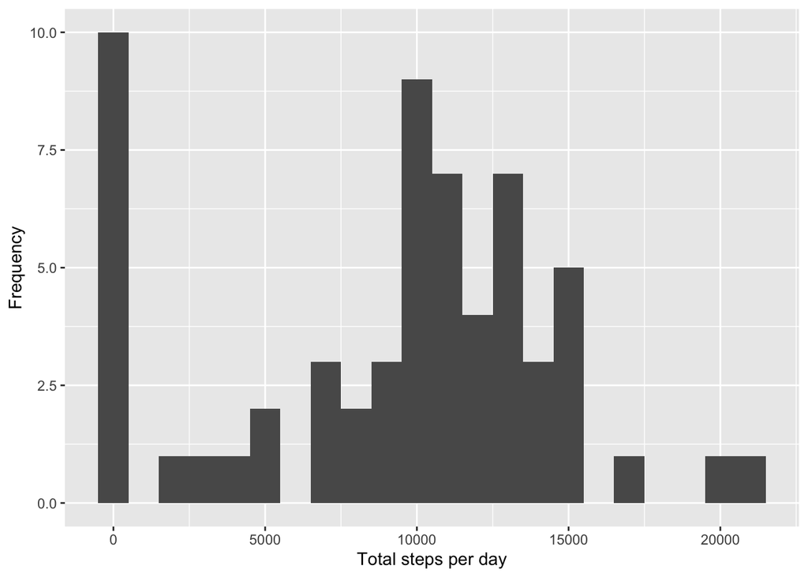

```r
qplot(stepsPerDay, xlab='Total steps per day', ylab='Frequency', binwidth=1000)
```

### TASK 4: Calculate and report the mean and median of the total number of steps taken per day

```r
stepsPerDayMean <- mean(stepsPerDay)
stepsPerDayMedian <- median(stepsPerDay)
```

- Mean: 9354.2295082
- Median: 10395

### TASK 5: What is the average daily activity pattern?

```r
adap <- aggregate(x=list(meanSteps=data$steps), by=list(interval=data$interval), FUN=mean, na.rm=TRUE)
```

### TASK 5.1: Creating the plot

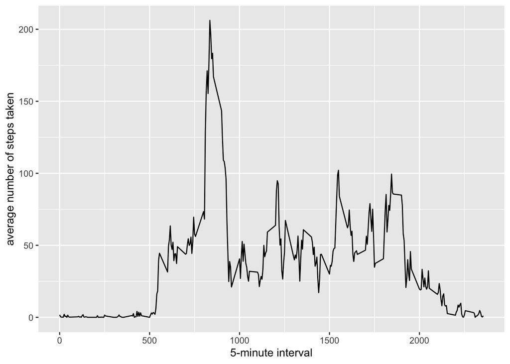

```r
ggplot(data=adap, aes(x=interval, y=meanSteps)) +
    geom_line() +
    xlab("5-minute interval") +
    ylab("average number of steps taken")
```

### TASK 5.2: Which 5-minute interval, on average across all the days in the dataset, contains the maximum number of steps?

```r
maxSteps <- which.max(adap$meanSteps)
timeMaxSteps <-  gsub("([0-9]{1,2})([0-9]{2})", "\\1:\\2", adap[maxSteps,'interval'])
```

- Maximum Steps at: 8:35

### TASK 6: Imputing missing values

### TASK 6.1: Calculate and report the total number of missing values in the dataset (i.e. the total number of rows with NA NAs)

```r
totalNumRowsNA <- length(which(is.na(data$steps)))
```

- Number of missing values: 2304

### TASK 6.2: Devise a strategy for filling in all of the missing values in the dataset

### TASK 6.3: Create a new dataset that is equal to the original dataset but with the missing data filled in.

```r
newData <- data
newData$steps <- impute(newData$steps, fun=mean)
```

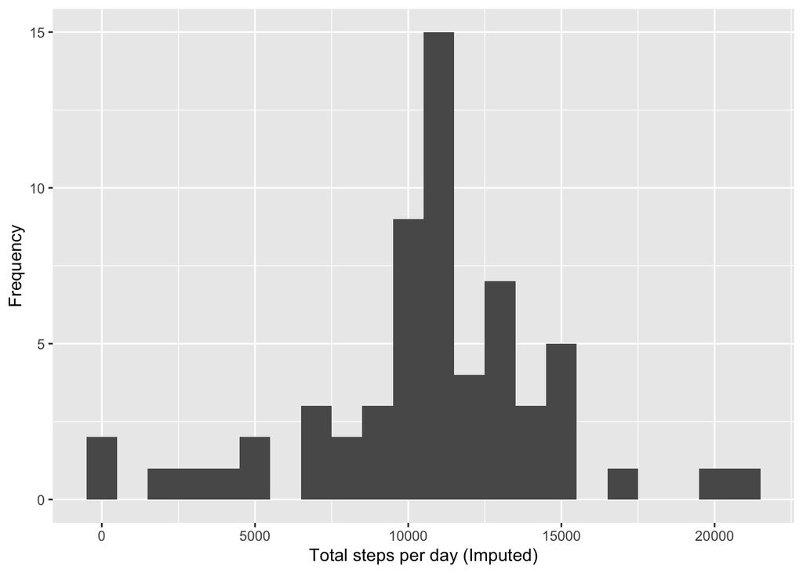

```r
stepsPerDayImp <- tapply(newData$steps, newData$date, sum)
qplot(stepsPerDayImp, xlab='Total steps per day (Imputed)', ylab='Frequency', binwidth=1000)
```

```r
stepsPerDayMeanImp <- mean(stepsPerDayImp)
stepsPerDayMedianImp <- median(stepsPerDayImp)
```

### TASK 7.1: Are there differences in activity patterns between weekdays and weekends?

```r
newData$dateType <-  ifelse(as.POSIXlt(newData$date)$wday %in% c(0,6), 'weekend', 'weekday')
```

### TASK 7.2: Are there differences in activity patterns between weekdays and weekends?

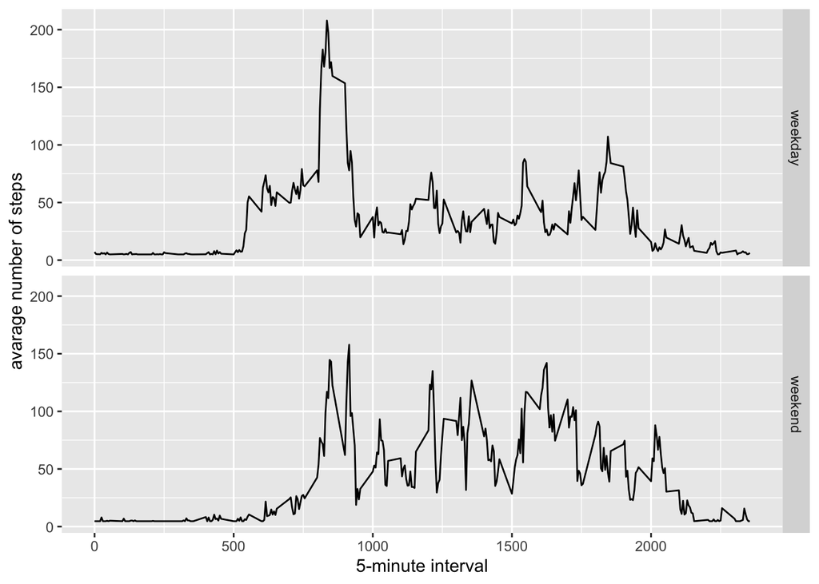

```r
avgDataImp <- aggregate(steps ~ interval + dateType, data=newData, mean)
ggplot(avgDataImp, aes(interval, steps)) +
    geom_line() +
    facet_grid(dateType ~ .) +
    xlab("5-minute interval") +
    ylab("avarage number of steps")
```